# Statistical Programming in R: Lecture 10

Dates

Josemari Feliciano

Fall 2024 - November 19

## Note

This is a converted long version of the Lecture 10 slides.

## Administrative: Final Project and Exam

Detailed information about both were shared last lecture.

1. Final project presentation: you will present your analysis during our December 3rd class. Under Week 8 on Canvas, there is a detailed document titled **Final Project Presentation Expectations.doc** which lists my clear expectation for your presentation materials. **Note to non-presenters:** I reserve the right to include one to two final exam questions on any material or insight presented by your peers.
2. Per the official Final Exam Schedule Calendar for Fall 2024, our final exam will be held on Tuesday, Dec 10, 2024 at 05:30 PM - 08:00PM. It will be cumulative. Same format: open book, you may take the exam anywhere. Exam will be written so that it can completed and submitted by most of you within the first 90-100 mins like the first midterm. I’ll be in the classroom if you want to take it in person which will allow you to ask clarifying questions.

## Other Administrative Items

Per university policy: November 26th (Tuesday): “Tuesday classes cancelled; Friday classes meet”

# Today’s agenda

- Chapter 17: Dates and times using lubridate (a core-tidyverse package)
- Things to learn outside this course post-DATA 412/612.

# Before we continue

Load the tidyverse and load the customer_data into your R env’t:

```r
library(tidyverse)
customer_data <- read_csv("https://github.com/jmtfeliciano/teachingdata/raw/refs/heads/main/customer_data_time_stamps.csv")
```

## Two common date formats in R data frames

These two formats follow the ISO8601 international standards. If the file you are reading them from (e.g., csv file) follows these format, R’s readr package and its tools (e.g., `read_csv()`) would automatically load them into your R env’t as date and dttm type.

- **date**: which has the ‘date’ data type (see data print out).
- **date-time**: which has the ‘POSIXct’ or ‘dttm’ data type (see data print out).

```r
glimpse(customer_data |> select(RegistrationDate, PurchaseDateTime))
```

```
## Rows: 100
## Columns: 2
## $ RegistrationDate <date> 2023-12-27, 2022-01-09, 2022-07-27, 2022-05-14, 2022…
## $ PurchaseDateTime <dttm> 2023-06-08 13:13:54, 2023-10-16 05:33:49, 2023-05-08…
```

# Working with non-ISO8601 standard date format

Let us view the full imported **customer_data** table:

```r
glimpse(customer_data)
```

```
## Rows: 100
## Columns: 5
## $ CustomerID       <dbl> 1, 2, 3, 4, 5, 6, 7, 8, 9, 10, 11, 12, 13, 14, 15, 16…
## $ RegistrationDate <date> 2023-12-27, 2022-01-09, 2022-07-27, 2022-05-14, 2022…
## $ PurchaseDateTime <dttm> 2023-06-08 13:13:54, 2023-10-16 05:33:49, 2023-05-08…
## $ date3_us_mdy     <chr> "06/08/2023", "10/16/2023", "05/08/2023", "07/26/2023…
## $ date4_world_dmy  <chr> "08/06/2023", "16/10/2023", "08/05/2023", "26/07/2023…
```

Both date3_us_mdy and date4_world_dmy were imported as chr (string) because they don’t follow the ISO8601 international standards.

date3_us_mdy is simply a date object in month/day/year format.

date4_world_dmy is simply a date object in day/month/year format.

# Working with non-ISO8601 standard date format

Two general ways to ensure that dates is not stored as chr (strings) in your final data table:

1. **Method 1:** When you use `read_csv()`, specify the expected format so it is read into the date type right away.
2. **Method 2 (my preferred):** When you use `read_csv()`, allow the dates to be read into R as chr (string) but later convert the string-version date into date data type. This method uses lubridate functions/tools.

## Method 1: `read_csv()` method

**Issue:** we need a way to tell `read_csv()` the specific format to expect when loading the csv data into R.

For example, how do tell R to expect the month/day/year format for date3_us_mdy so the column can be read into R as date type instead of char (string) type?

```r
glimpse(customer_data)
```

```
## Rows: 100
## Columns: 5
## $ CustomerID       <dbl> 1, 2, 3, 4, 5, 6, 7, 8, 9, 10, 11, 12, 13, 14, 15, 16…
## $ RegistrationDate <date> 2023-12-27, 2022-01-09, 2022-07-27, 2022-05-14, 2022…
## $ PurchaseDateTime <dttm> 2023-06-08 13:13:54, 2023-10-16 05:33:49, 2023-05-08…
## $ date3_us_mdy     <chr> "06/08/2023", "10/16/2023", "05/08/2023", "07/26/2023…
## $ date4_world_dmy  <chr> "08/06/2023", "16/10/2023", "08/05/2023", "26/07/2023…
```

## Method 1: `read_csv()` method

You may think of the table below as the ingredients needed to tell R what to expect for the date data you are working with. This table of date-time format is accepted in many other programming languages.

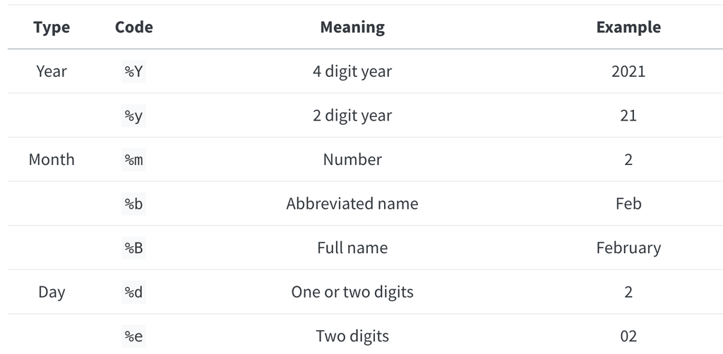

Figure 1. date-time format in many programming language

## Method 1: `read_csv()` method

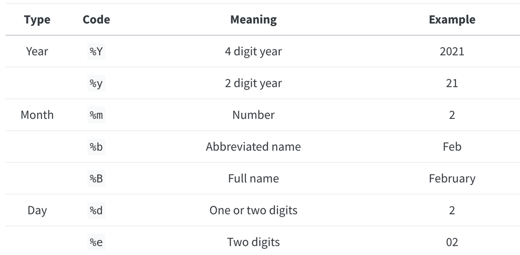

Figure 1. date-time format in many programming language

**Conversion of selected date stamp formats and their date-time equivalent formats (i.e., how to tell R the date format to expect):**

1. “06/08/2023” (example from date3_us_mdy) => “%m/%e/%Y”
2. “08/06/2023” (example from date4_world_dmy) => “%e/%m/%Y”
3. “Mar 2 21” => “%b %d %y”
4. “April 9 2021” => “%B %d %Y”

## Method 1: `read_csv()` method

Now that we know the date-time equivalent formats for date3_us_mdy and date4_world_dmy, we can now specify to R what to expect so the columns are loaded as date type instead of chr (string) type.

Let us focus on date3_us_mdy for now. For this, we will need to add `col_types = cols([variable] = col_date([format]))` as demonstrated below inside `read_csv()`:

```r
customer_data_v2 <- read_csv("https://github.com/jmtfeliciano/teachingdata/raw/refs/heads/main/customer_data_time_stamps.csv",
                             col_types = cols(date3_us_mdy = col_date("%m/%e/%Y")))
glimpse(customer_data_v2)
```

```
## Rows: 100
## Columns: 5
## $ CustomerID       <dbl> 1, 2, 3, 4, 5, 6, 7, 8, 9, 10, 11, 12, 13, 14, 15, 16…
## $ RegistrationDate <date> 2023-12-27, 2022-01-09, 2022-07-27, 2022-05-14, 2022…
## $ PurchaseDateTime <dttm> 2023-06-08 13:13:54, 2023-10-16 05:33:49, 2023-05-08…
## $ date3_us_mdy     <date> 2023-06-08, 2023-10-16, 2023-05-08, 2023-07-26, 2023…
## $ date4_world_dmy  <chr> "08/06/2023", "16/10/2023", "08/05/2023", "26/07/2023…
```

*Note that date3_us_mdy is no longer chr (string) and now of date type.*

## Method 1: `read_csv()` method

Now let us do date3_us_mdy and date4_world_dmy at the same time:

```r
customer_data_v3 <- read_csv("https://github.com/jmtfeliciano/teachingdata/raw/refs/heads/main/customer_data_time_stamps.csv",
                             col_types = cols(date3_us_mdy = col_date("%m/%e/%Y"),
                                              date4_world_dmy = col_date("%e/%m/%Y")))
glimpse(customer_data_v3)
```

```
## Rows: 100
## Columns: 5
## $ CustomerID       <dbl> 1, 2, 3, 4, 5, 6, 7, 8, 9, 10, 11, 12, 13, 14, 15, 16…
## $ RegistrationDate <date> 2023-12-27, 2022-01-09, 2022-07-27, 2022-05-14, 2022…
## $ PurchaseDateTime <dttm> 2023-06-08 13:13:54, 2023-10-16 05:33:49, 2023-05-08…
## $ date3_us_mdy     <date> 2023-06-08, 2023-10-16, 2023-05-08, 2023-07-26, 2023…
## $ date4_world_dmy  <date> 2023-06-08, 2023-10-16, 2023-05-08, 2023-07-26, 2023…
```

*Note that date3_us_mdy and date4_world_dmy are no longer chr (string) and now of date type.*

## Method 2: use lubridate functions mdy() and dmy()

lubridate’s mdy() and dmy() functions/tools are handy. Very intelligent tool.

Here are non-table examples briefly (we will revisit customer_data next page):

```r
mdy("January 31st, 2017")
```

```
## [1] "2017-01-31"
```

```r
mdy("January 31, 17")
```

```
## [1] "2017-01-31"
```

```r
dmy("31-Jan-2017")
```

```
## [1] "2017-01-31"
```

```r
dmy("Created on 31st Jan 2017")
```

```
## [1] "2017-01-31"
```

## Method 2: use lubridate functions mdy() and dmy()

```r
glimpse(customer_data) # before mdy() use
```

```
## Rows: 100
## Columns: 5
## $ CustomerID       <dbl> 1, 2, 3, 4, 5, 6, 7, 8, 9, 10, 11, 12, 13, 14, 15, 16…
## $ RegistrationDate <date> 2023-12-27, 2022-01-09, 2022-07-27, 2022-05-14, 2022…
## $ PurchaseDateTime <dttm> 2023-06-08 13:13:54, 2023-10-16 05:33:49, 2023-05-08…
## $ date3_us_mdy     <chr> "06/08/2023", "10/16/2023", "05/08/2023", "07/26/2023…
## $ date4_world_dmy  <chr> "08/06/2023", "16/10/2023", "08/05/2023", "26/07/2023…
```

Let us focus on date3_us_mdy for now. We now that the chr (string) version is in mdy format, so let us use mdy() from lubridate with mutate below to override date3_us_mdy.

```r
customer_data_v4 <- customer_data |>
  mutate(date3_us_mdy = mdy(date3_us_mdy))

glimpse(customer_data_v4)
```

```
## Rows: 100
## Columns: 5
## $ CustomerID       <dbl> 1, 2, 3, 4, 5, 6, 7, 8, 9, 10, 11, 12, 13, 14, 15, 16…
## $ RegistrationDate <date> 2023-12-27, 2022-01-09, 2022-07-27, 2022-05-14, 2022…
## $ PurchaseDateTime <dttm> 2023-06-08 13:13:54, 2023-10-16 05:33:49, 2023-05-08…
## $ date3_us_mdy     <date> 2023-06-08, 2023-10-16, 2023-05-08, 2023-07-26, 2023…
## $ date4_world_dmy  <chr> "08/06/2023", "16/10/2023", "08/05/2023", "26/07/2023…
```

## Method 2: use lubridate functions mdy() and dmy()

An example where we do both at the same time:

```r
customer_data_v5 <- customer_data |>
  mutate(date3_us_mdy = mdy(date3_us_mdy),
         date4_world_dmy = dmy(date4_world_dmy))

glimpse(customer_data_v5)
```

```
## Rows: 100
## Columns: 5
## $ CustomerID       <dbl> 1, 2, 3, 4, 5, 6, 7, 8, 9, 10, 11, 12, 13, 14, 15, 16…
## $ RegistrationDate <date> 2023-12-27, 2022-01-09, 2022-07-27, 2022-05-14, 2022…
## $ PurchaseDateTime <dttm> 2023-06-08 13:13:54, 2023-10-16 05:33:49, 2023-05-08…
## $ date3_us_mdy     <date> 2023-06-08, 2023-10-16, 2023-05-08, 2023-07-26, 2023…
## $ date4_world_dmy  <date> 2023-06-08, 2023-10-16, 2023-05-08, 2023-07-26, 2023…
```

## Let us revisit flights data: using `make_date()`

This is an example where year, month, and day are in separate columns.

```r
flights <- read_rds("https://github.com/jmtfeliciano/teachingdata/raw/refs/heads/main/flights.rds") |>
  select(year, month, day, dep_delay, carrier, flight)

head(flights)
```

```
## # A tibble: 6 × 6
##    year month   day dep_delay carrier flight
##   <int> <int> <int>     <dbl> <chr>    <int>
## 1  2013     1    10        -6 DL         706
## 2  2013     5    16        -8 MQ        4426
## 3  2013    11    11        -4 AS           5
## 4  2013     4    24        -7 AA        1097
## 5  2013    11    20        -5 EV        3849
## 6  2013     9    11        -1 B6         183
```

## Let us revisit flights data: using `make_date()`

To make one single date type column, we may use lubridate’s `make_date([year variable], [month variable], [day variable])`

```r
flights_v2 <- flights |>
  mutate(date = make_date(year, month, day)) |>
  relocate(date)


head(flights_v2)
```

```
## # A tibble: 6 × 7
##   date        year month   day dep_delay carrier flight
##   <date>     <int> <int> <int>     <dbl> <chr>    <int>
## 1 2013-01-10  2013     1    10        -6 DL         706
## 2 2013-05-16  2013     5    16        -8 MQ        4426
## 3 2013-11-11  2013    11    11        -4 AS           5
## 4 2013-04-24  2013     4    24        -7 AA        1097
## 5 2013-11-20  2013    11    20        -5 EV        3849
## 6 2013-09-11  2013     9    11        -1 B6         183
```

## filter() and date objects

Examples below using ymd():

```r
# an example where we filter for data where date is before November 1st, 2013
flights_v2 |>
  filter(date < ymd("2013-11-01"))

# an example where we filter between two dates
flights_v2 |>
  filter(between(date, ymd("2013-11-01"), ymd("2013-11-30")))

# an example where we filter for data between two dates
flights_v2 |>
  filter(date >= ymd("2013-11-01") & date <= ymd("2013-11-30"))
```

## Date objects and ggplot: time-series plot.

One benefit of date objects in R is that we can easily create line graphs with the date on the x-axis and some form of statistic on the y-axis. For this example, let us create flights_v3 which calculates the average departure delay for each date within the data set.

```r
flights_v3 <- flights_v2 |>
  group_by(date) |>
  summarise(mean_dep_delay = mean(dep_delay, na.rm = T))
head(flights_v3)
```

```
## # A tibble: 6 × 2
##   date       mean_dep_delay
##   <date>              <dbl>
## 1 2013-01-01          10.2
## 2 2013-01-02          12.9
## 3 2013-01-03          11.6
## 4 2013-01-04           8.41
## 5 2013-01-05           4.62
## 6 2013-01-06           5.69
```

## Date objects and ggplot: time-series plot.

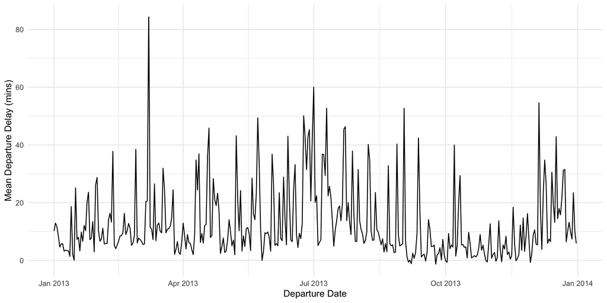

```r
ggplot(flights_v3, aes(x = date, y = mean_dep_delay)) +
  geom_line() +
  labs(x = "Departure Date", y = "Mean Departure Delay (mins)") +
  theme_minimal() # this one removes the ugly grey background
```

## What to learn post DATA-412/612: Non-R Materials.

- One cool aspect of being a data scientist: you always get to learn new things (e.g., new programming languages, statistical models, new technology stack).
- Learn Python on top of R.
- Learn SQL.
- Get familiar with cloud platforms (e.g., Google Cloud, AWS, Azure).
- Get familiar with dashboarding tools (e.g., PowerBI, Tableau).

## What to learn post DATA-412/612: R Packages.

- For maps and geospatial data: sf, tidycensus, leaflet.
- For static and interactive dashboards: flexdashboard, shiny, plotly.

> My example that uses both: https://jmtfeliciano.github.io/HIVPreventionDashboard
- For basic NLP (text mining, sentiment analysis): tidytext
- For time-series forecasting (e.g., ARIMA): forecast, arima

## What to learn post DATA-412/612: R Packages.

- Revisit all the R packages we learned.
- Glance over our textbook via https://r4ds.hadley.nz/

> I’ve compiled detailed cheatsheets (which includes many functions/tools we didn’t go over) here: https://github.com/jmtfeliciano/teachingdata/tree/main/TidyversePackagesCheatsheet

## What to learn post DATA-412/612: Intro to Machine Learning.

[figure not shown]

Figure 2. Image of the ‘An Introduction to Statistical Learning’ Book, which is free. Free PDF copy in statlearning.com/

## What to learn post DATA-412/612: Advanced Statistics Topics

- Bayesian statistics: rjags, rstan.
- Causal Inference: https://www.r-causal.org/

## What to learn post DATA-412/612: A future RStudio Alternative

Posit, the company that owns RStudio, is currently developing a new alternative to RStudio called Positron. Positron will be optimized for both R and Python use.

For more information about Positron, you may visit if you want to try the pre-release (beta version): https://positron.posit.co/

## Open Discussion

If you have them, I will answer all your general questions about R, RStudio, or data science as a field.

## Thank you

I really love teaching R and thank you for being an awesome class.

I do hope the slow pace of the course enabled you to learn R in a low-stress environment. This course is designed this way by the Data Science program at AU.

Feel free to contact me in the future after this course for any R and data science questions you may have. I am unsure how much longer I will teach here at AU but my permanent email is jfeliciano@alumni.harvard.edu. You may also add me on linkedin via linkedin.com/in/jmtfeliciano

## Download Exercise10.qmd from Canvas and open in R. You have 25 mins to complete this. Then I will go over the solution.